# Student Performance Data Analysis Report

Author

Zuoming Hu

## 1 **Introduction**

### 1.1 Background and context

Student academic performance directly impacts academic advancement and employment, and also provides a basis for school resource allocation and teaching improvements. Data for 2,392 students were considered in this analysis. The dependent variable is GPA (0–4 scale), and GradeClass is used for grouping purposes only. The primary independent variables under consideration are study duration weekly, absences, and the family support variables (tutoring, parental, and extracurricular/sports/music/volunteering). Factors considered in the background variables including gender, ethnicity, and level of education of the parents are age.

### 1.2 Research question and hypotheses

How much of an impact do study behavior and family support have on GPA, controlling for the background variables? H1: Time spent studying and GPA are positively related; H2: Absences and GPA are inversely related; H3: Participation in tutoring and higher parental support are positively correlated with GPA; H4: The impact of extracurricular activities on GPA is heterogeneous (to be tested in direction).

### 1.3 Report structure

Section 2 describes the data and the cleaning process; Section 3 provides the descriptive statistics as well as EDA; Section 4 details the methods and the diagnostics, including a comparison of the OLS and Lasso approaches; Section 5 delivers the results and an executive summary at the start; Section 6 analyzes the findings and their limitations; Section 7 offers the conclusion along with policy recommendations. This is followed by references and appendices.

## 2 **Data Description**

### 2.2 Data dictionary

Table 1: Data Dictionary

[output not shown]

### 2.3 Data cleaning/preprocessing steps

During the preprocessing phase, we examined each variable for missing values, ranges, and completeness, confirming that all values fell within reasonable ranges. The data was complete and ready for immediate use. We then recoded the numeric values for categorical variables into labeled factors for better readability and easier reference group setting and coefficient interpretations. Gender included the labels Male and Female; ethnicity was simplified to Caucasian, African American, Asian, and Other; parental education was grouped as None, High School, Some College, Bachelor, and Higher; tutoring and participation in extracurricular activities were categorized as No and Yes; and parental support was classified as None, Low, Moderate, High, and Very High. GradeClass was for grouping and quality assurance purposes only and was excluded from the regression modeling. For coefficient interpretability, the main analysis was kept on the original scale, while continuous variables were standardized to z-scores for comparison across models, particularly in Lasso.

Figure 1: Boxplot of GPA Scores

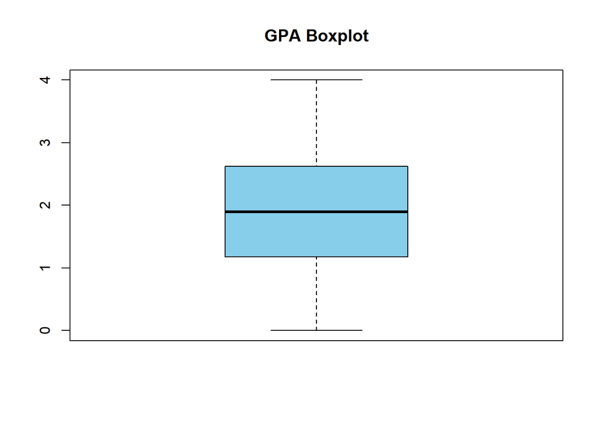

## 3 **Exploratory Data Analysis**

### 3.1 Overview of GPA Distribution

Table 2: Summary Statistics of Student GPA and Grade Distribution

```
   A    B    C    D    F
 107  269  391  414 1211
```

```
         A          B          C          D          F
0.04473244 0.11245819 0.16346154 0.17307692 0.50627090
```

```
   Min. 1st Qu.  Median    Mean 3rd Qu.    Max.
  0.000   1.175   1.893   1.906   2.622   4.000
```

Exploratory Data Analysis showed that the range of GPAs were between 0 and 4 GPAs, with a mean of about 1.9, a median of 1.89, and a standard deviation of about 1.0 which suggest the distribution was approximately symmetrical. Grade class data showed that nearly half of the student population received Fs, with a small number receiving A’s, which suggest that the students showed underperformance academically.

Figure 2: Distribution of Student GPA

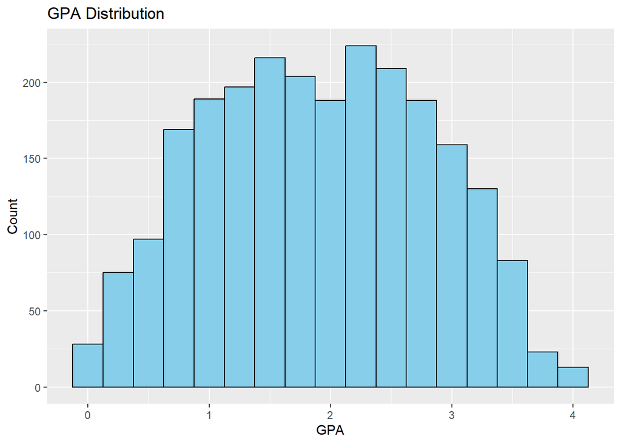

Figure 3: Distribution of Grade Classes Among Students

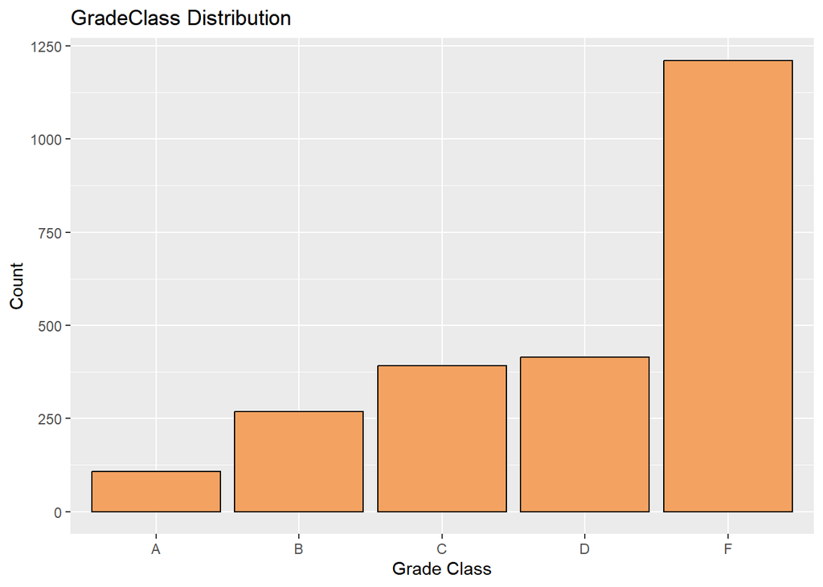

### 3.2 Learning Time and Attendance Patterns

Table 3: Correlation Between Study Time, Absences, and GPA

```
[1] 0.1792751
```

```
[1] -0.9193136
```

From the scatter plot, there were two correlations described; a slight positive correlation study time and GPA of about (r ≈ 0.18) which suggest that spending more time studying is associated with a slight increase in GPA, and significant negative correlation of (r ≈ -0.92) between GPA and absences which suggest that GPA is influenced by the absence of the student.

Figure 4: Relationship Between Weekly Study Time and GPA

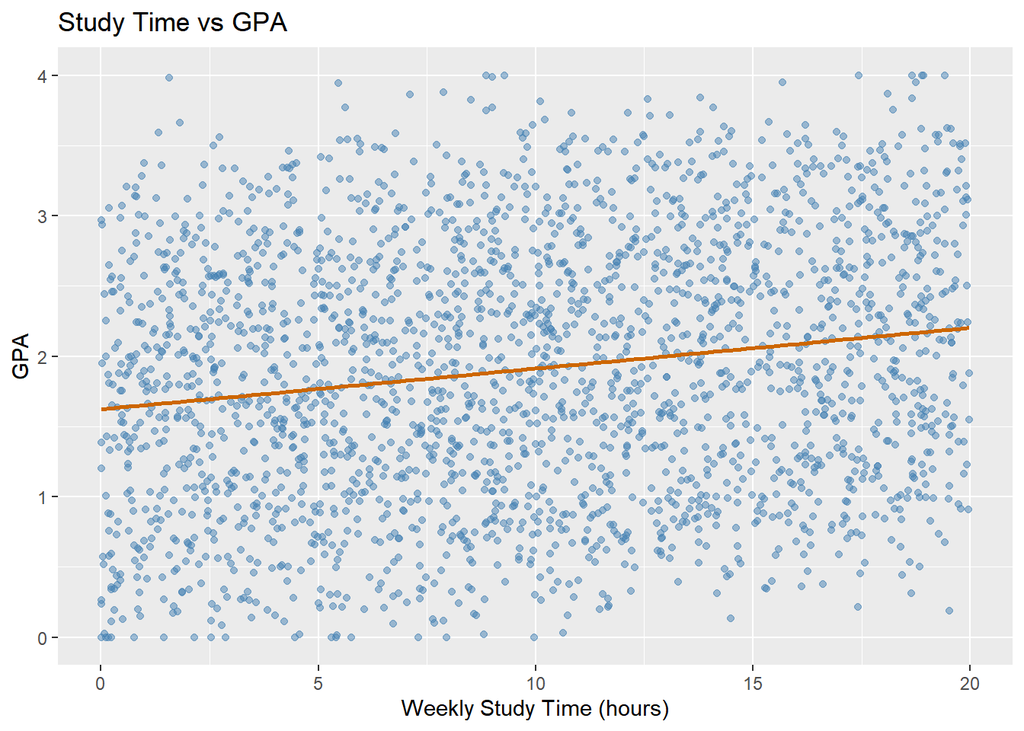

Figure 5: Relationship Between Number of Absences and GPA

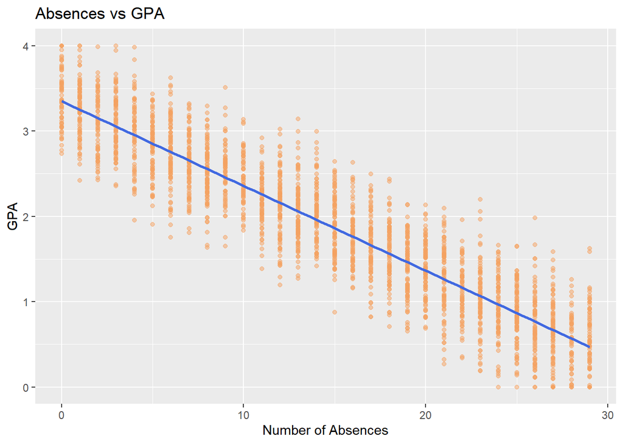

### 3.3 Family Support and Academic Engagement

Figure 6: GPA Distribution by Gender

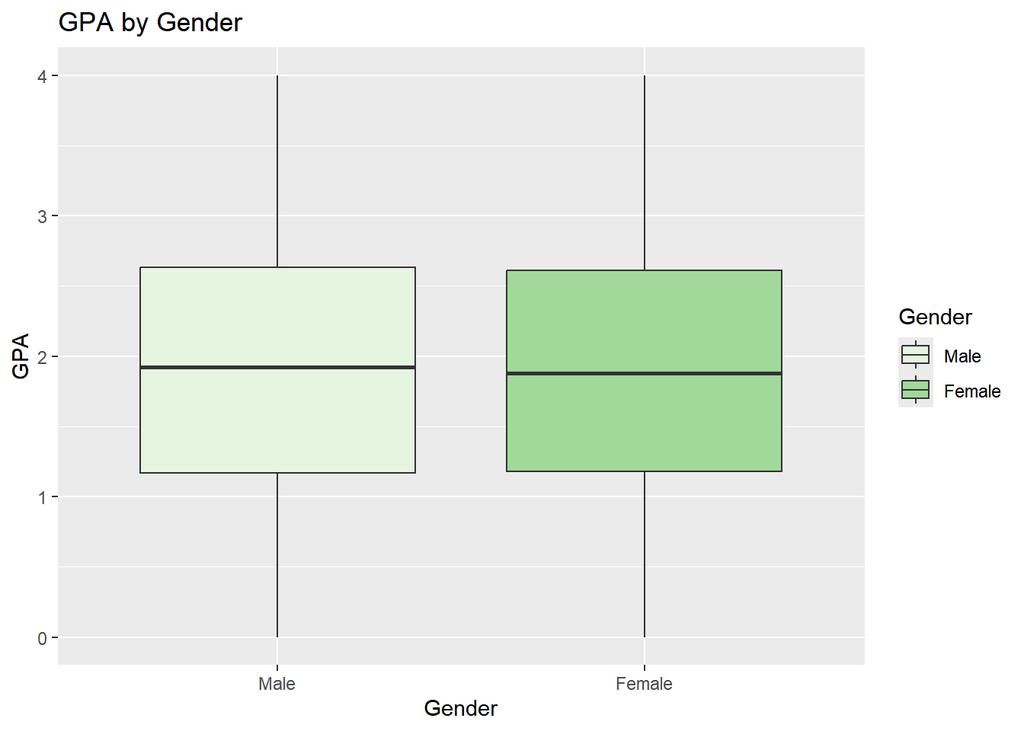

Figure 7: GPA Distribution by Parental Education Level

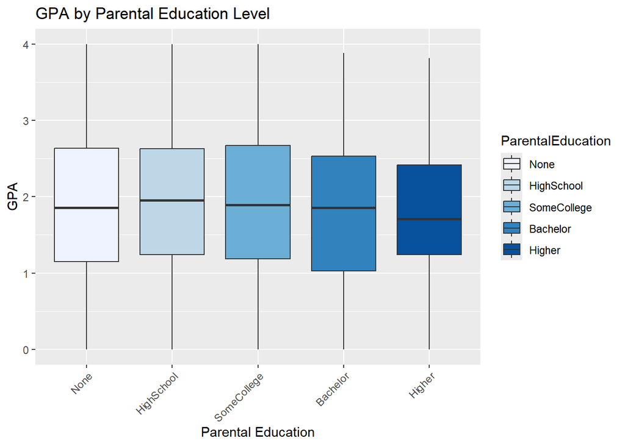

Figure 8: GPA Distribution by Parental Support Level

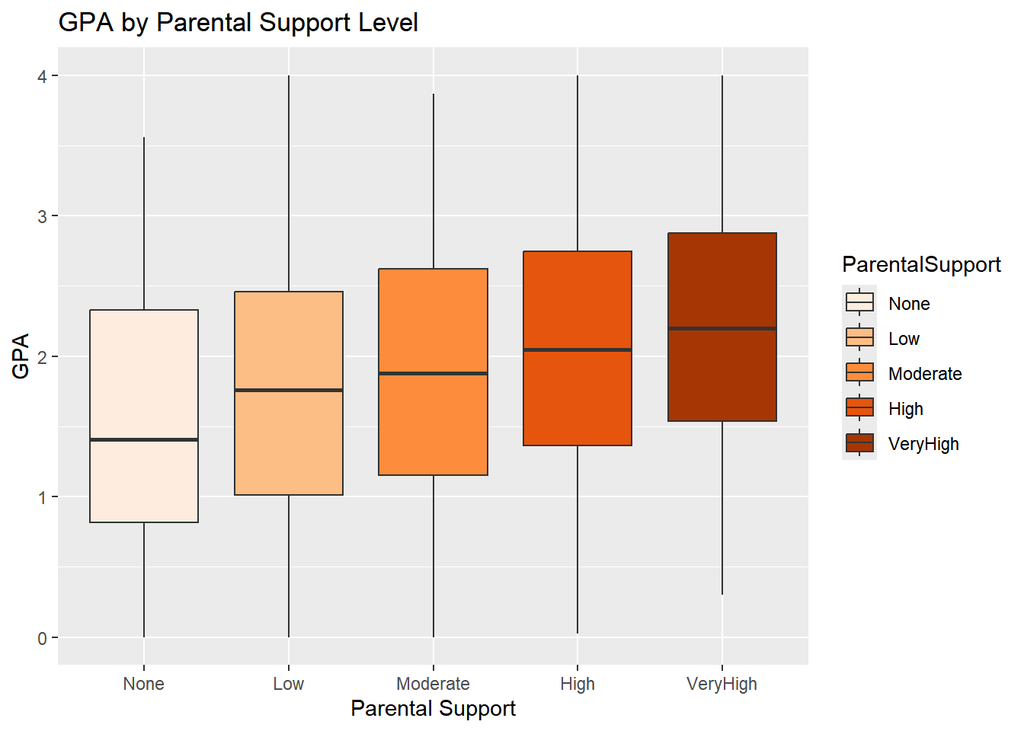

Figure 9: GPA Distribution by Tutoring Participation

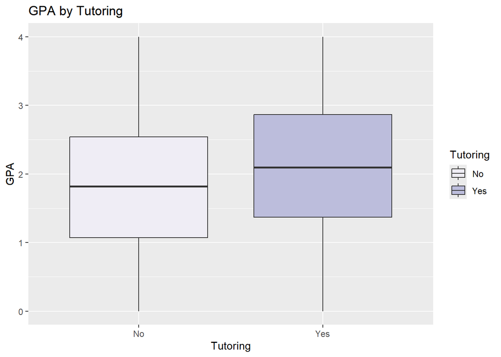

Figure 10: GPA Distribution by Extracurricular Participation

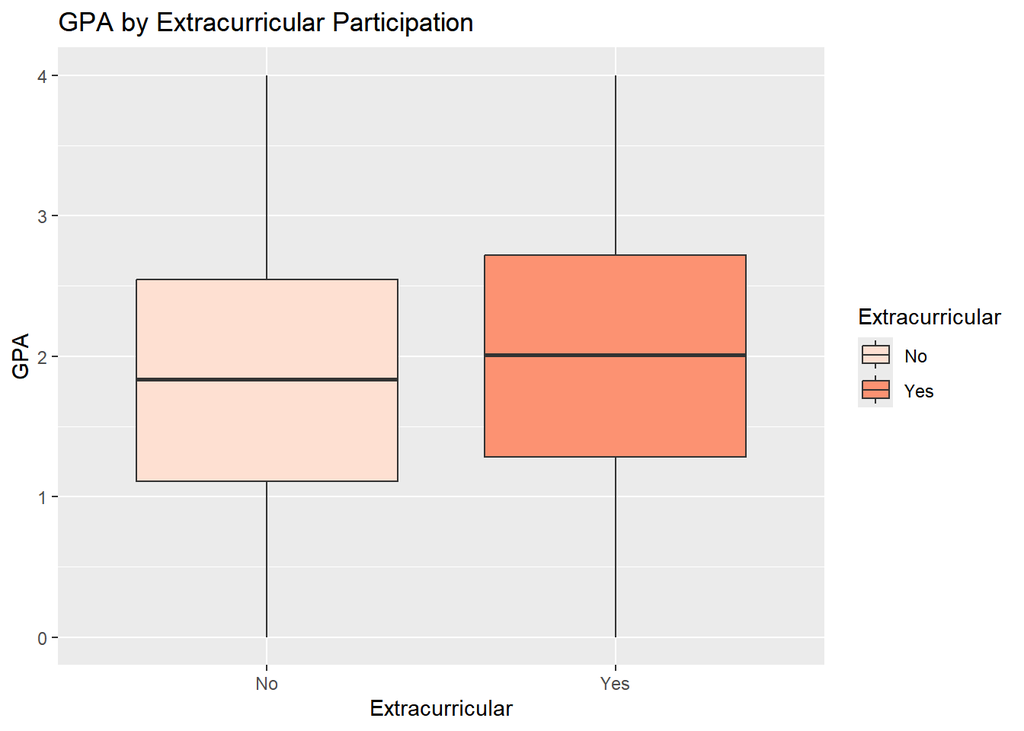

### 3.4 Group Differences and Parental Education

Table 4: Mean GPA by Parental Education Level

```
# A tibble: 5 × 2
  ParentalEducation mean_GPA
  <fct>                <dbl>
1 HighSchool            1.94
2 SomeCollege           1.93
3 None                  1.89
4 Higher                1.82
5 Bachelor              1.81
```

Table 5: Mean GPA by Parental Support Level

```
# A tibble: 5 × 2
  ParentalSupport mean_GPA
  <fct>              <dbl>
1 VeryHigh            2.19
2 High                2.04
3 Moderate            1.88
4 Low                 1.76
5 None                1.54
```

Table 6: Mean GPA by Tutoring Participation

```
# A tibble: 2 × 2
  Tutoring mean_GPA
  <fct>       <dbl>
1 No           1.82
2 Yes          2.11
```

Table 7: Mean GPA by Extracurricular Participation

```
# A tibble: 2 × 2
  Extracurricular mean_GPA
  <fct>              <dbl>
1 No                  1.84
2 Yes                 2.02
```

The differences between groups show that there are family and resource-related factors that are linked to achievement. The support from parents shows an increasing gradient: from None to Very High, the average GPAs spanned from 1.54 to 2.19. The students who participated in tutoring (about 2.11 versus 1.82) and in extracurricular activities (about 2.02 versus 1.84) had higher average GPAs compared to those students who did not participate. Overall, the impact of parental education on GPA did vary, but not in an outright linear manner; some groups had crossing means, and there were also no considerable differences in GPA by gender.

### 3.5 Summary of Key Insights

Study time, attendance, family support, and academic engagement all likely predict a student’s GPA, while the influence of parents’ education level is minimal. Such findings would be informative for the following regression analyses, indicating that the examination of the linear effect of these variables on academic performance would be appropriate.

## 4 **Methodology**

### 4.1 Model Construction and Variable Selection

Utilizing students’ GPAs as the dependent variable, the study undertook the construction of multiple linear regression and lasso regression models to analyze the effects of family factors and learning behaviors on academic performance. Weekly study time, number of unscheduled absences, family support, tutoring and extracurricular activity involvement, and gender were classified as independent variables. These predictors were chosen based on hypotheses (H1–H4) discussed earlier which state that study time will be positively correlated with GPA, absences will be negatively correlated with GPA, and family support alongside the expectations of academic engagement will positively influence academic performance.

### 4.2 Lasso Regression Technique and Model Evaluation Criteria

Figure 11: 10-Fold Cross-Validation for Lasso Regression

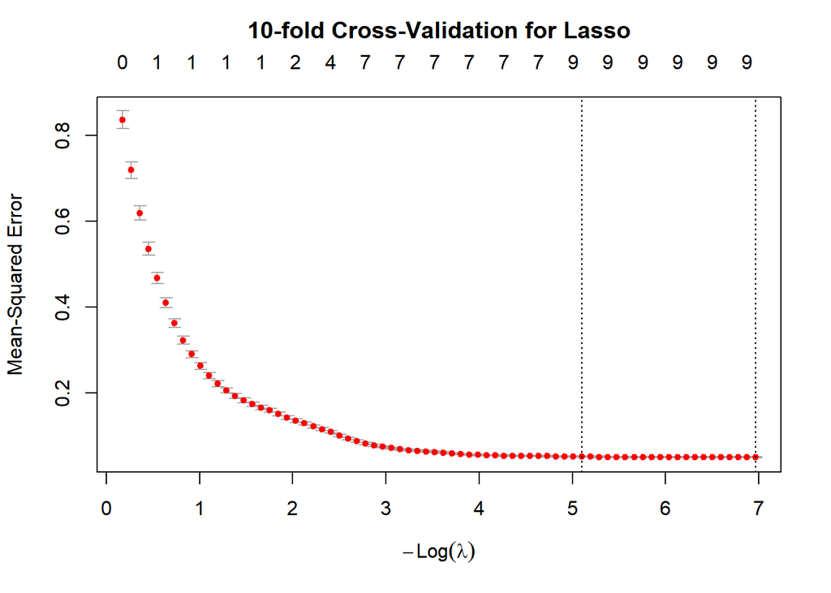

### 4.3 Model Fitting and Diagnostic Testing

The results of the OLS model fit show that the R² equaled 0.9408 and the adjusted R² was 0.9406, which means that the variance of the GPA returns was approximately 94% explained by the model. To improve predictive robustness while avoiding overfitting, the Lasso model was constructed with a 10-fold cross validation along with λmin = 0.0009, the optimal penalty parameter. To test that the regression model satisfies the classical linear regression assumptions, I constructed residual diagnostic plots. Most importantly, the residual-fit plot shows good homogeneity of variance, the QQ plot is almost diagonal, the scale-location plot shows no outliers and, the leverage and VIFs, which are both below 2, show no multicollinearity.

Figure 12: Residuals vs Fitted Plot

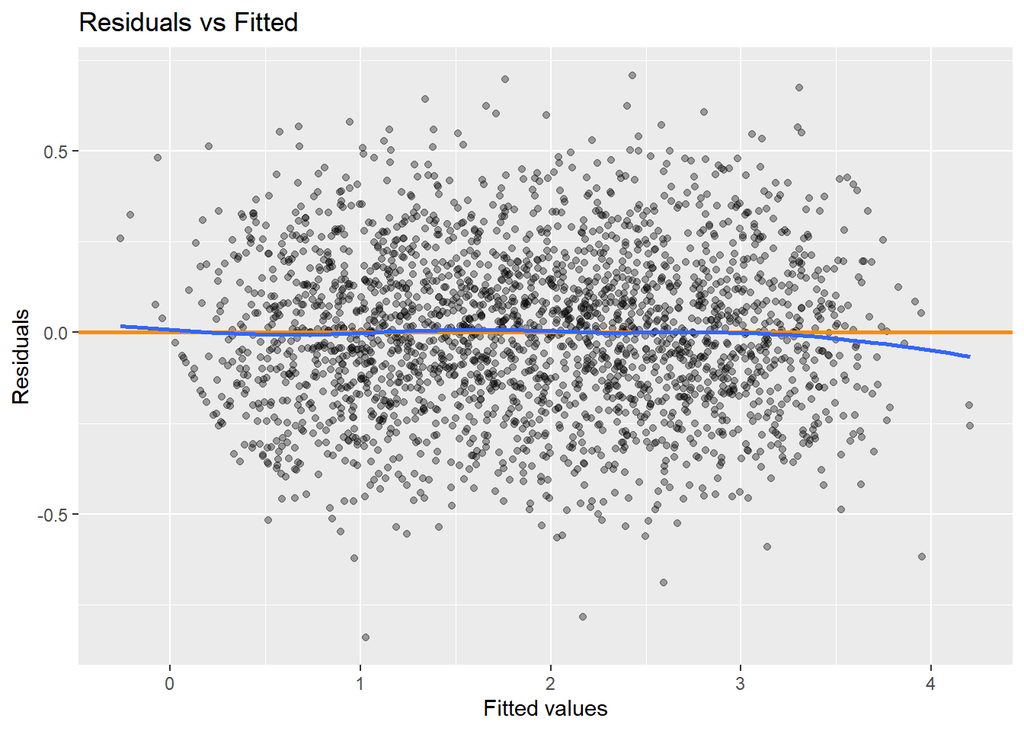

Figure 13: Normal Q–Q Plot

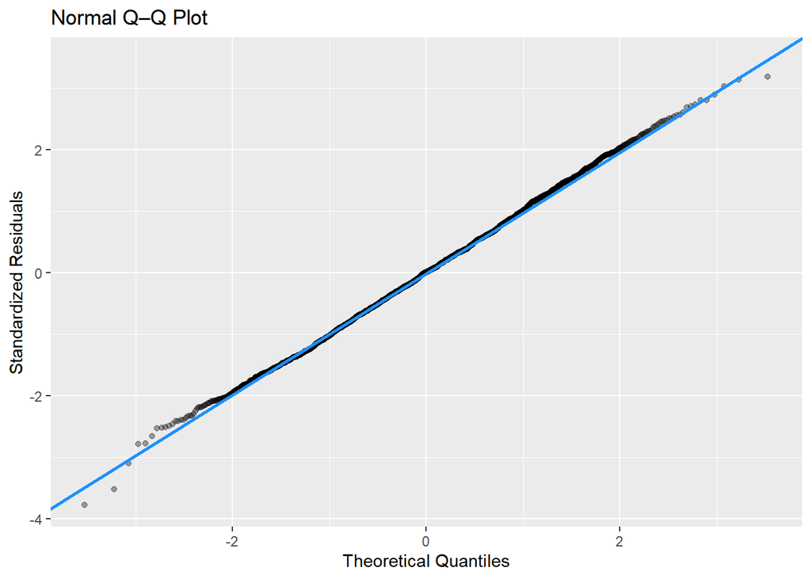

Figure 14: Scale–Location Plot

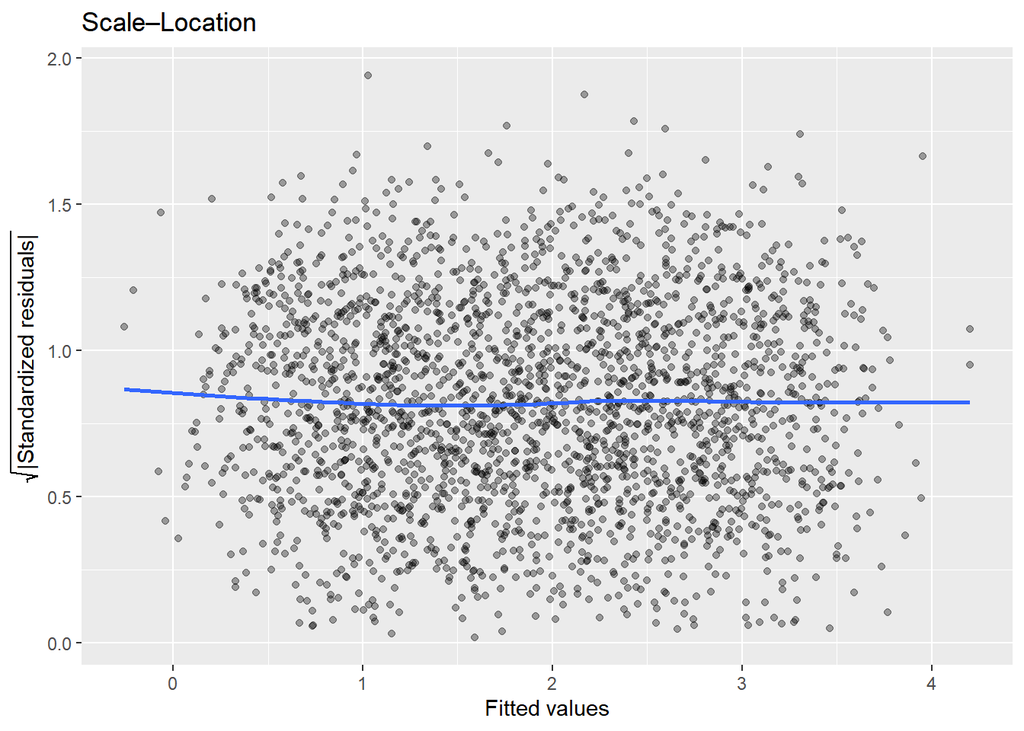

Figure 15: Residuals vs Leverage Plot

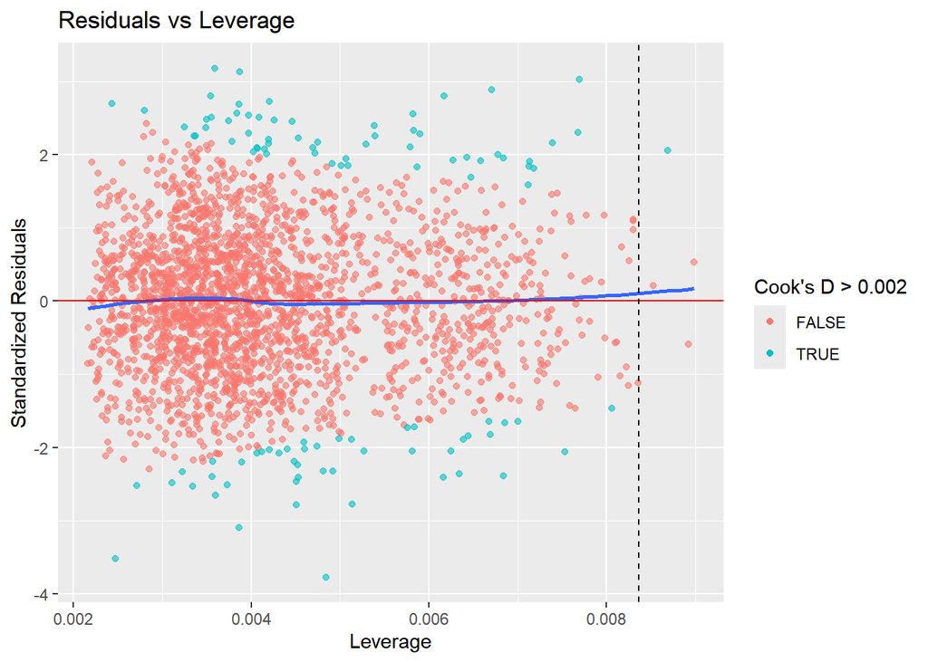

### 4.4 Model Comparison and Final Selection

Table 8: Model Performance Comparison Between OLS and Lasso Regression

```
                             Model        MSE       MAE
1 Multiple Linear Regression (OLS) 0.04951829 0.1779173
2                 Lasso Regression 0.04955621 0.1781311
```

## 5 **Results**

### 5.1 Executive Summary

The data shows that class participation, absenteeism, and family support are among the primary determinants affecting student GPA. Every absence account for a drop of 0.10 in GPA. On the other hand, every additional hour spent studying a week translates to an increase of 0.03 to their GPA. With respect to family support, the positive effects are more pronounced the greater that support is, though effects are still present at lower levels. The accuracy of the OLS and Lasso methods is similar (R²≈0.94, MAE≈0.18), providing consistent evidence for the main conclusions. Although OLS models should be reported for ease of interpretation and communication, for practical use, more emphasis should be placed on Lasso, as it will yield a more streamlined selection of variables under error approximation. Thus, we recommend that resources be prioritized for attendance warning and intervention (to mitigate the considerable negative impact of absences), consolidation of weekly study time (to achieve small but incremental improvements), and enhancement of home-school partnership and tutoring alignment to tackle substantial grade improvements in the first few weeks of the semester.

### 5.2 Model Results and Diagnostics

Table 9: Model Performance Comparison (OLS vs Lasso Regression)

| Model | R2 | Adj_R2 | MSE | MAE |
| --- | --- | --- | --- | --- |
| Multiple Linear Regression (OLS) | 0.9408 | 0.9406 | 0.0495 | 0.1779 |
| Lasso Regression | NA | NA | 0.0496 | 0.1781 |

Diagnostics indicate no issues with the assumptions (see Figures 12–13): the residuals do not show a funnel pattern; the QQ plot points follow the 45° line closely; the scale-location and leverage plots indicate only a few high-leverage cases; and all the VIFs are under 2. This shows that the model is reliable and is well specified.

Table 10: Comparison of Key Predictors between OLS and Lasso Models

[output not shown]

The main indicators are consistent across different predictions (refer to Table 10). The most significant negative influence are absences (≈ -0.10 GPA for each absence). The positive influence of study time is also modest (≈ +0.03 for every hour studied). The effect of parental support increases systematically from Low to Very High. There are positive associations with GPA for tutoring and extracurricular activities (≈ +0.25 and +0.19 respectively). The impact of gender (female) becomes irrelevant after controlling for other factors. These findings are consistent with previous descriptive trends; the main factors are attendance, study effort, and parental support and resources.

Given the similar error levels in Table 9, deploy Lasso for a more compact, easier to maintain model, and use OLS to communicate the effects as shown in Table 10. Prioritize attendance alerts and timely interventions first (avoiding one absence ≈ +0.10 GPA), then stable weekly study routines (+0.03 for every extra hour), and more robust home–school coordination and tutoring for at-risk students.

### 5.3 Implications of the Results

Set the sequence of actions as attendance first, then study hours, then family/tutoring. Start with reminders, mentor check-ins, and school-home contact to get high-absence students back on track. Afterwards, establish a weekly study schedule. Instruct on time management techniques and determine certain study periods. Studies have shown that light monitoring with brief, frequent practice sessions enhance study efficiency. After this, reinforce tutoring and extracurricular activities, and seek for parental involvement to create a consistent learning atmosphere. Role models are apparent. To obtain a lean risk score that is simple to implement and manage, use Lasso as the operations models for risk; on the communications side, use OLS to create visuals (dashboards/key-point charts) that show the marginal effect and importance of each element to assist teachers and parents in understanding. Maintain a weekly rhythm with an active focus for the first 3-4 weeks. The primary KPIs will focus on monitoring attendance, study hours per week, and measuring the GPA increase. Working with students the model marks as high risk first, then adjust the weekly objectives to show clear, consistent progress.

## 6 **Discussion**

### 6.1 Validation of Key Hypotheses

The study substantiated the principal hypotheses H1–H3. Academic engagement and family support are substantial determinants of students’ GPAs, while absenteeism significantly deteriorates academic performance. The correlation between attendance and study time with grades supports the educational psychology theory correlating academic engagement and performance. The effects of parental support and academic tutoring also suggest the importance of the family environment in student learning outcomes.

### 6.3 Limitations and Future Considerations

While the high fit of the model is acknowledged, it is important to point out the weaknesses of the model. First, the cross-sectional nature of the data and the absence of more complex control variables, the unique explanatory value of causal assertions, and the self-report variables that could be impacted by subjective bias. Lastly, absence of possible factors on the model, such as learning motivation, psychological well-being, and the quality of the teacher, may not allow the model to fully develop its explanatory capability. More longitudinal research and additional psychosocial variables could aid in further elucidating the results, particularly in the case of the more dynamic effects of learning engagement and learning design support in the family on academic outcomes.

## 7 **Conclusion**

This study examined the influence that academic engagement, attendance, and family support have on grade point average (GPA) using data from 2,392 students. Study time, absences, and parental support emerged as the greatest predictors of GPA: more study time and greater parental support correlated with higher academic achievement, while absences correlated with lower achievement. Comparative analyses and model diagnostics confirmed the consistency of the OLS and Lasso model outputs, which validated the defense of the research conclusions.

These findings suggest the importance of research behavioral factors. The support from family and the school is of utmost importance in achieving academic success. Practitioners in education should prioritize strategies that enhance students’ study habits and academic engagement, absences, and strengthen school-parent partnerships, including targeted tutoring and homework assistance.

Additionally, the research could analyze psychological variables, motivation, and social-economic status together with data on teacher effectiveness, in order to study the performance variables from a longitudinal perspective and provide policymakers with data on academic performance.

## 8 **References**

- Cite R

  R Core Team (2023). *R: A Language and Environment for Statistical Computing*. R Foundation for Statistical Computing, Vienna, Austria. [https://www.R-project.org](https://www.r-project.org/)
- Cite R Packages used

  Fox, J., & Weisberg, S. (2019). *An R companion to applied regression* (3rd ed.) [R package]. Sage Publications. https://CRAN.R-project.org/package=car

  Friedman, J., Hastie, T., & Tibshirani, R. (2023). *glmnet: Lasso and elastic-net regularized generalized linear models* [R package]. R package version 4.1-8. https://CRAN.R-project.org/package=glmnet

  Wickham, H. (2016). *ggplot2: Elegant graphics for data analysis* [R package]. Springer-Verlag. https://ggplot2.tidyverse.org

  Wickham, H., François, R., Henry, L., & Müller, K. (2023). *dplyr: A grammar of data manipulation* [R package]. R package version 1.1.3. https://CRAN.R-project.org/package=dplyr
- Data set

  Azam, M. (2024). *Student Performance Data: An Analytical Dataset Exploring Academic Performance Factors among Students*. Kaggle. https://www.kaggle.com/datasets/muhammadazam121/student-performance-data

  Kharoua, R. E. (2023). *Students performance dataset: Academic success factors in high school students* [Data set]. Kaggle. https://www.kaggle.com/datasets/rabieelkharoua/students-performance-dataset

## 9 **Appendices**

- Dataset Structure Overview

```r
dim(data)
```

```
[1] 2392   15
```

```r
str(data)
```

```
'data.frame':   2392 obs. of  15 variables:
 $ StudentID        : int  1001 1002 1003 1004 1005 1006 1007 1008 1009 1010 ...
 $ Age              : int  17 18 15 17 17 18 15 15 17 16 ...
 $ Gender           : Factor w/ 2 levels "Male","Female": 2 1 1 2 2 1 1 2 1 2 ...
 $ Ethnicity        : Factor w/ 4 levels "Caucasian","AfricanAmerican",..: 1 1 3 1 1 1 2 2 1 1 ...
 $ ParentalEducation: Factor w/ 5 levels "None","HighSchool",..: 3 2 4 4 3 2 2 5 1 2 ...
 $ StudyTimeWeekly  : num  19.83 15.41 4.21 10.03 4.67 ...
 $ Absences         : int  7 0 26 14 17 0 10 22 1 0 ...
 $ Tutoring         : Factor w/ 2 levels "No","Yes": 2 1 1 1 2 1 1 2 1 1 ...
 $ ParentalSupport  : Factor w/ 5 levels "None","Low","Moderate",..: 3 2 3 4 4 2 4 2 3 4 ...
 $ Extracurricular  : Factor w/ 2 levels "No","Yes": 1 1 1 2 1 2 1 2 1 2 ...
 $ Sports           : Factor w/ 2 levels "No","Yes": 1 1 1 1 1 1 2 1 2 1 ...
 $ Music            : Factor w/ 2 levels "No","Yes": 2 1 1 1 1 1 1 1 1 1 ...
 $ Volunteering     : Factor w/ 2 levels "No","Yes": 1 1 1 1 1 1 1 1 2 1 ...
 $ GPA              : num  2.929 3.043 0.113 2.054 1.288 ...
 $ GradeClass       : Factor w/ 5 levels "A","B","C","D",..: 3 2 5 4 5 2 3 5 3 1 ...
```

```r
summary(data)
```

```
   StudentID         Age           Gender               Ethnicity
 Min.   :1001   Min.   :15.00   Male  :1170   Caucasian      :1207
 1st Qu.:1599   1st Qu.:15.00   Female:1222   AfricanAmerican: 493
 Median :2196   Median :16.00                 Asian          : 470
 Mean   :2196   Mean   :16.47                 Other          : 222
 3rd Qu.:2794   3rd Qu.:17.00
 Max.   :3392   Max.   :18.00
   ParentalEducation StudyTimeWeekly        Absences     Tutoring
 None       :243     Min.   : 0.001057   Min.   : 0.00   No :1671
 HighSchool :728     1st Qu.: 5.043079   1st Qu.: 7.00   Yes: 721
 SomeCollege:934     Median : 9.705363   Median :15.00
 Bachelor   :367     Mean   : 9.771992   Mean   :14.54
 Higher     :120     3rd Qu.:14.408410   3rd Qu.:22.00
                     Max.   :19.978094   Max.   :29.00
 ParentalSupport Extracurricular Sports     Music      Volunteering
 None    :212    No :1475        No :1666   No :1921   No :2016
 Low     :489    Yes: 917        Yes: 726   Yes: 471   Yes: 376
 Moderate:740
 High    :697
 VeryHigh:254

      GPA        GradeClass
 Min.   :0.000   A: 107
 1st Qu.:1.175   B: 269
 Median :1.893   C: 391
 Mean   :1.906   D: 414
 3rd Qu.:2.622   F:1211
 Max.   :4.000
```

- Missing Values and Unique Value Count

```r
colSums(is.na(data))
```

```
        StudentID               Age            Gender         Ethnicity
                0                 0                 0                 0
ParentalEducation   StudyTimeWeekly          Absences          Tutoring
                0                 0                 0                 0
  ParentalSupport   Extracurricular            Sports             Music
                0                 0                 0                 0
     Volunteering               GPA        GradeClass
                0                 0                 0
```

```r
sapply(data, function(x) length(unique(x)))
```

```
        StudentID               Age            Gender         Ethnicity
             2392                 4                 2                 4
ParentalEducation   StudyTimeWeekly          Absences          Tutoring
                5              2392                30                 2
  ParentalSupport   Extracurricular            Sports             Music
                5                 2                 2                 2
     Volunteering               GPA        GradeClass
                2              2371                 5
```

- Data Type Conversion and Factor Encoding

```r
data <- data |>
  mutate(
    Gender = factor(Gender,
                    levels = c(0,1),
                    labels = c("Male","Female")),
    Ethnicity = factor(Ethnicity,
                       levels = c(0,1,2,3),
                       labels = c("Caucasian","AfricanAmerican","Asian","Other")),
    ParentalEducation = factor(ParentalEducation,
                               levels = 0:4,
                               labels = c("None","HighSchool",
                                          "SomeCollege","Bachelor","Higher")),
    Tutoring = factor(Tutoring,
                      levels = c(0,1),
                      labels = c("No","Yes")),
    ParentalSupport = factor(ParentalSupport,
                             levels = 0:4,
                             labels = c("None","Low","Moderate",
                                        "High","VeryHigh")),
    Extracurricular = factor(Extracurricular,
                             levels = c(0,1),
                             labels = c("No","Yes")),
    Sports = factor(Sports,
                    levels = c(0,1),
                    labels = c("No","Yes")),
    Music = factor(Music,
                   levels = c(0,1),
                   labels = c("No","Yes")),
    Volunteering = factor(Volunteering,
                          levels = c(0,1),
                          labels = c("No","Yes")),
    GradeClass = factor(GradeClass,
                        levels = 0:4,
                        labels = c("A","B","C","D","F"))
  )
```

- OLS Model Construction and Summary Statistics

```r
# OLS Model
summary(model_lm)
```

```
Call:
lm(formula = form_full, data = data)

Residuals:
     Min       1Q   Median       3Q      Max
-0.83895 -0.15091  0.00132  0.14484  0.70855

Coefficients:
                          Estimate Std. Error  t value Pr(>|t|)
(Intercept)              2.5872388  0.0199596  129.624   <2e-16 ***
StudyTimeWeekly          0.0291040  0.0008083   36.005   <2e-16 ***
Absences                -0.0993912  0.0005389 -184.444   <2e-16 ***
ParentalSupportLow       0.1594936  0.0183589    8.688   <2e-16 ***
ParentalSupportModerate  0.3052764  0.0173766   17.568   <2e-16 ***
ParentalSupportHigh      0.4563067  0.0174959   26.081   <2e-16 ***
ParentalSupportVeryHigh  0.6198917  0.0207528   29.870   <2e-16 ***
TutoringYes              0.2502339  0.0099479   25.154   <2e-16 ***
ExtracurricularYes       0.1872148  0.0093880   19.942   <2e-16 ***
GenderFemale             0.0133074  0.0091326    1.457    0.145
---
Signif. codes:  0 '***' 0.001 '**' 0.01 '*' 0.05 '.' 0.1 ' ' 1

Residual standard error: 0.223 on 2382 degrees of freedom
Multiple R-squared:  0.9408,    Adjusted R-squared:  0.9406
F-statistic:  4210 on 9 and 2382 DF,  p-value: < 2.2e-16
```

```r
# R²
ols_r2
```

```
[1] 0.9408497
```

```r
# Adjusted R²
ols_ar2
```

```
[1] 0.9406262
```

```r
# F-test
ols_f
```

```
   value
4209.809
```

- Lasso Regression and Model Comparison

```r
X <- model.matrix(form_full, data = data)[, -1]
y <- data$GPA

set.seed(123)
cv_lasso <- cv.glmnet(X, y, alpha = 1, nfolds = 10, standardize = TRUE)

lambda_min <- cv_lasso$lambda.min
lambda_1se <- cv_lasso$lambda.1se

pred_lm <- predict(model_lm, newdata = data)
mse_lm <- mean((data$GPA - pred_lm)^2)
mae_lm <- mean(abs(data$GPA - pred_lm))

pred_lasso <- as.numeric(predict(cv_lasso, newx = X, s = "lambda.min"))
mse_lasso <- mean((y - pred_lasso)^2)
mae_lasso <- mean(abs(y - pred_lasso))

comp_models <- data.frame(
  Model = c("Multiple Linear Regression (OLS)", "Lasso Regression"),
  MSE = c(mse_lm, mse_lasso),
  MAE = c(mae_lm, mae_lasso)
)

diag_df <- data.frame(
  fitted       = fitted(model_lm),
  resid        = resid(model_lm),
  stdres       = rstandard(model_lm),
  leverage     = hatvalues(model_lm),
  cooks        = cooks.distance(model_lm)
)
```

```
[1] 0.000944872
```

```
[1] 0.006073706
```

```
10 x 1 sparse Matrix of class "dgCMatrix"
                         lambda.min
(Intercept)              2.60800717
StudyTimeWeekly          0.02893535
Absences                -0.09928606
ParentalSupportLow       0.13896723
ParentalSupportModerate  0.28515269
ParentalSupportHigh      0.43628094
ParentalSupportVeryHigh  0.59869343
TutoringYes              0.24833478
ExtracurricularYes       0.18544536
GenderFemale             0.01156497
```

```
                             Model        MSE       MAE
1 Multiple Linear Regression (OLS) 0.04951829 0.1779173
2                 Lasso Regression 0.04955621 0.1781311
```

- Model Diagnostics and Multicollinearity Check

```r
# Heteroskedasticity test
ncvTest(model_lm)
```

```
Non-constant Variance Score Test
Variance formula: ~ fitted.values
Chisquare = 0.2121038, Df = 1, p = 0.64512
```

```r
# Detection of multicollinearity
vif(model_lm)
```

```
                    GVIF Df GVIF^(1/(2*Df))
StudyTimeWeekly 1.003891  1        1.001943
Absences        1.001071  1        1.000535
ParentalSupport 1.005378  4        1.000671
Tutoring        1.002367  1        1.001183
Extracurricular 1.002222  1        1.001110
Gender          1.002541  1        1.001270
```

```r
# Confidence intervals
confint(model_lm)
```

```
                               2.5 %      97.5 %
(Intercept)              2.548098907  2.62637870
StudyTimeWeekly          0.027518929  0.03068910
Absences                -0.100447896 -0.09833449
ParentalSupportLow       0.123492510  0.19549473
ParentalSupportModerate  0.271201501  0.33935124
ParentalSupportHigh      0.421997932  0.49061542
ParentalSupportVeryHigh  0.579196235  0.66058713
TutoringYes              0.230726487  0.26974129
ExtracurricularYes       0.168805242  0.20562434
GenderFemale            -0.004601299  0.03121613
```